# CS 422

### Part 1-D

```r
printcp(model)
```

[output not shown]

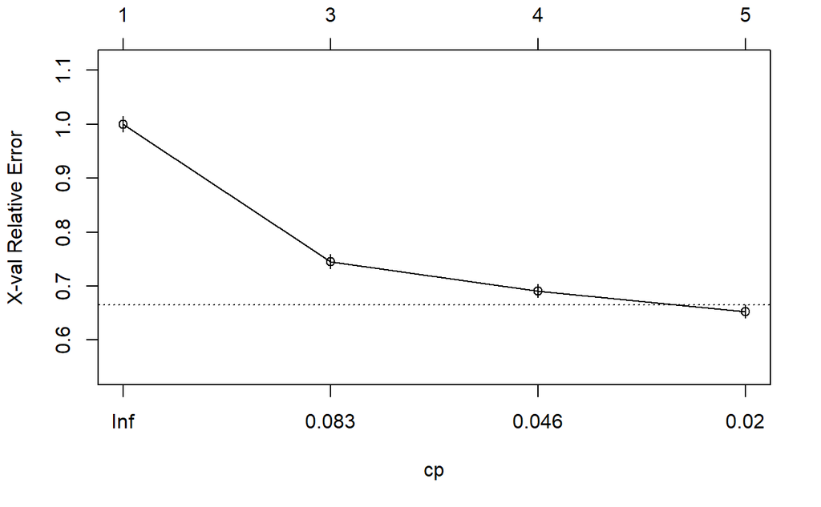

```r
plotcp(model)
```

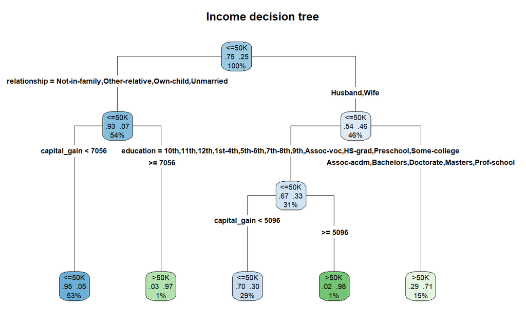

```r
cpx <- model$cptable[which.min(model$cptable[,"xerror"]), "CP"]
pruned.model <- prune(model, cp=cpx)
predic <- predict(pruned.model, test_c.df, type = "class")

rpart.plot(model, extra=104, fallen.leaves=T, type=4, main="Income decision tree")
```

In order to decide if the decision tree should be pruned or not, we have to look at the xerror and cp values. This last one is the threshold of impurity decrease that we admit on each split. In case of admitting one of the splits, the chosen split will be the one whose xerror is the lowest, in order to get the smallest final impurity, that is to say, the highest information gain.

Taking into account the plotted information, the decision tree should not be pruned. In case of having to prune the tree, we would choose the option with the lowest xerror value.

We decide not to prune it due to the fact that after having done several subtrees, the xerror continues decerasing, therefore it has not arrived to its minimum. This evolution of the function tells us that we have not arrived yet to the overfitting in which the xerror looses its monotical character and starts going up and down. Taking into account that making another subtree will not wind up in overfitting yet, we can also deduce that pruning the last tree will not be a good choice because we have clearance for making more subtrees without reaching the overfitting (prunning is suggested when the split number is that large that the overfitting is reached.).